# Longfin SQUIBS Biweekly Update

Week of 01/21/2024

**Cumulative Sample Summary**

Number of weeks sampled: **34**

Number of samples received: **66**

Number of samples processed: **66**

Number of individual squid processed to date: **8462**

**News/comments:**

- One hermaphroditic organism was found in a sample from 5Zw during week 40 (Week of October 1). It was found to have a fully-developed testis, spermatophores, and accessory glands, but no nidamental gland or ovary. The organism is currently preserved in the freezer at the Narragansett Lab.
- Dissection demonstrations were performed for the NMFS Leadership Council on November 29 and for students from the Knauss Fellowship program on December 8.
- Three longfin squid and information on the background and methods of the longfin SQUIBS project were given to Holly Morin of the University of Rhode Island for a dissection demonstration for 3rd graders.
- A virtual presentation on longfin SQUIBS and other Cooperative Research Branch squid projects is expected to be given to Cary Academy Middle School of Cary, NC on January 31.

## Cumulative results from 2023

### Lengths and Weights

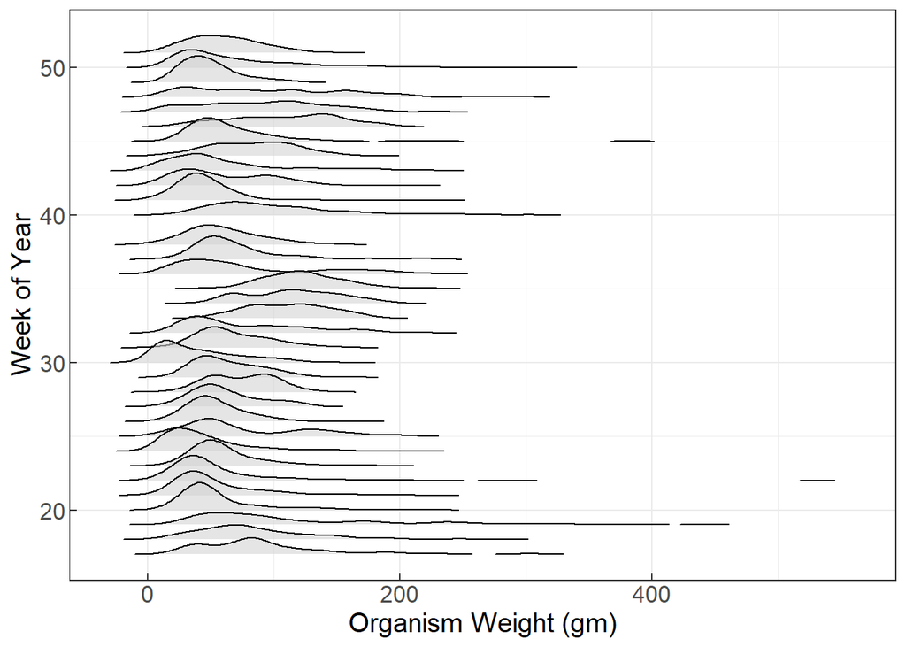

**Figure 1.** Organism weight frequency distributions over time for longfin squid samples collected in 2023. Data was collected from week 17 (week of April 23) to week 51 (week of December 17).

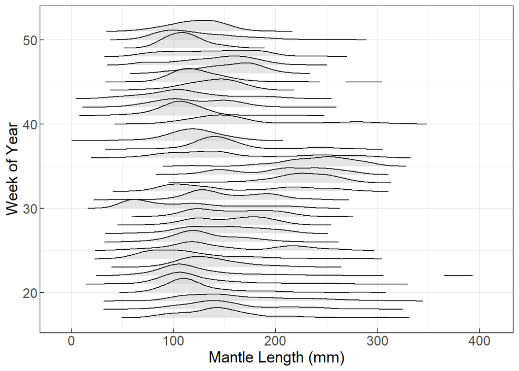

**Figure 2.** Organism length frequency distributions over time for longfin squid samples collected in 2023.

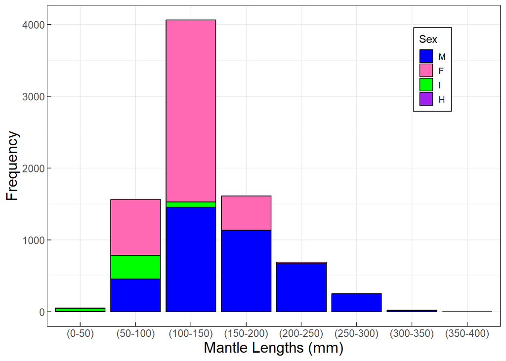

**Figure 3.** Mantle length frequencies across sex. Organisms identified as female are shown in pink, males are indicated by blue, individuals that could not be sexed (considered “Indeterminate”) are shown in green, and hermaphroditic organisms are represented in purple.

### Sex and Maturity

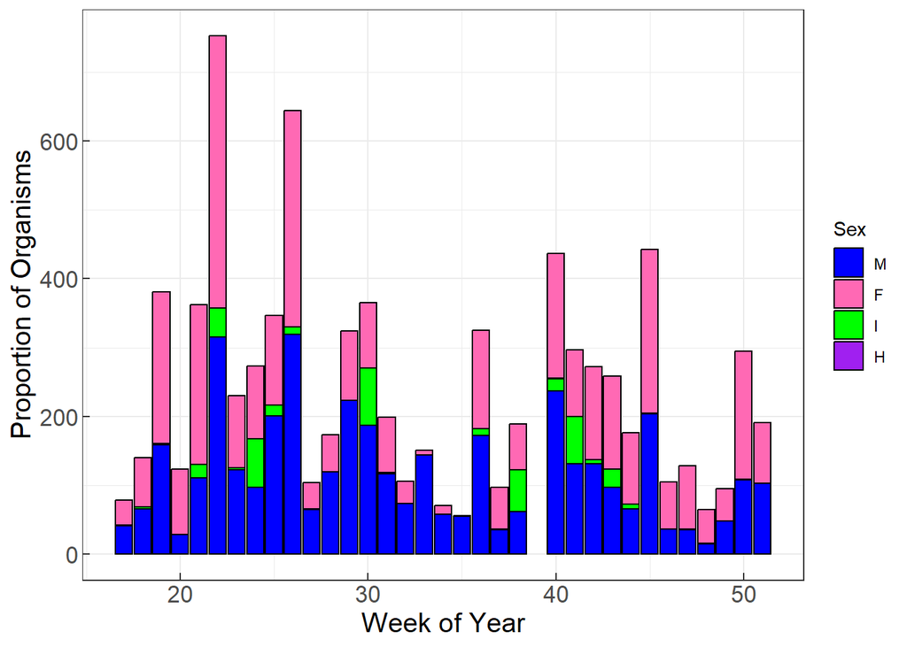

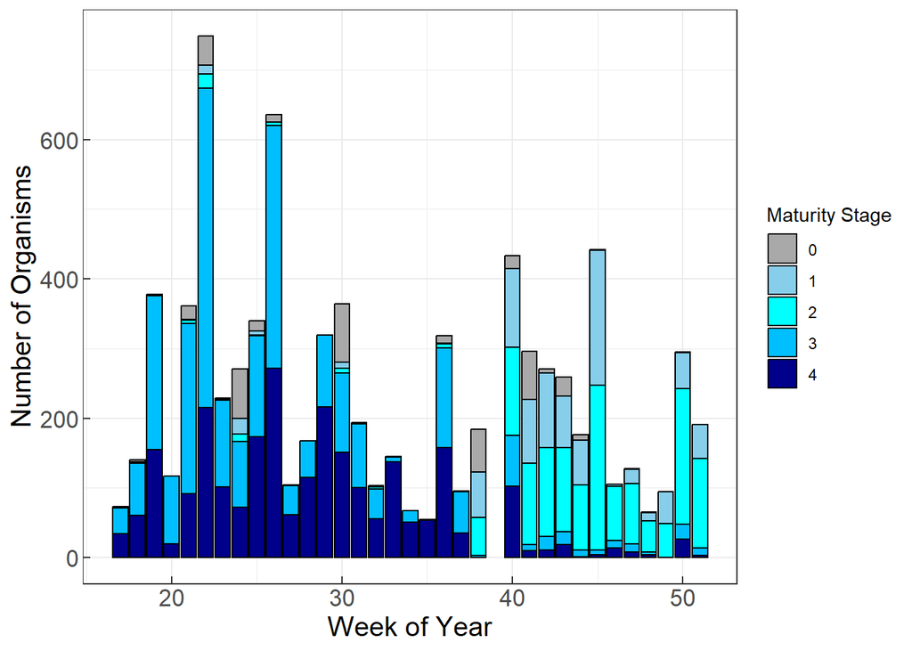

## Map

Reference map of potential collection locations. This project uses [NAFO Regulatory Areas](https://www.nafo.int/Fisheries/Fishing-Activity-in-the-NRA) as a point of reference from which to target fishing trips, in an effort to collect squid samples throughout a representative spatial range of the fishery.

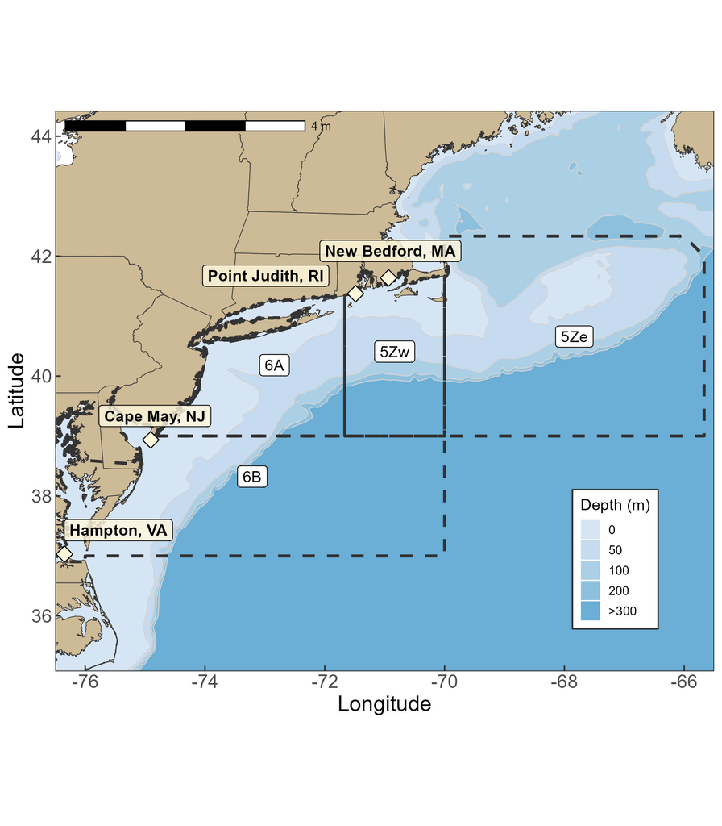

## Works Cited

Macy III WK. 1982. Development and application of an objective method for classifying long- finned squid, *Loligo pealei*, into sexual maturity stages. Fishery Bulletin. 80(3):449-59.